# Projeto Integrador - Livros de Data Science e Estatística da Amazon

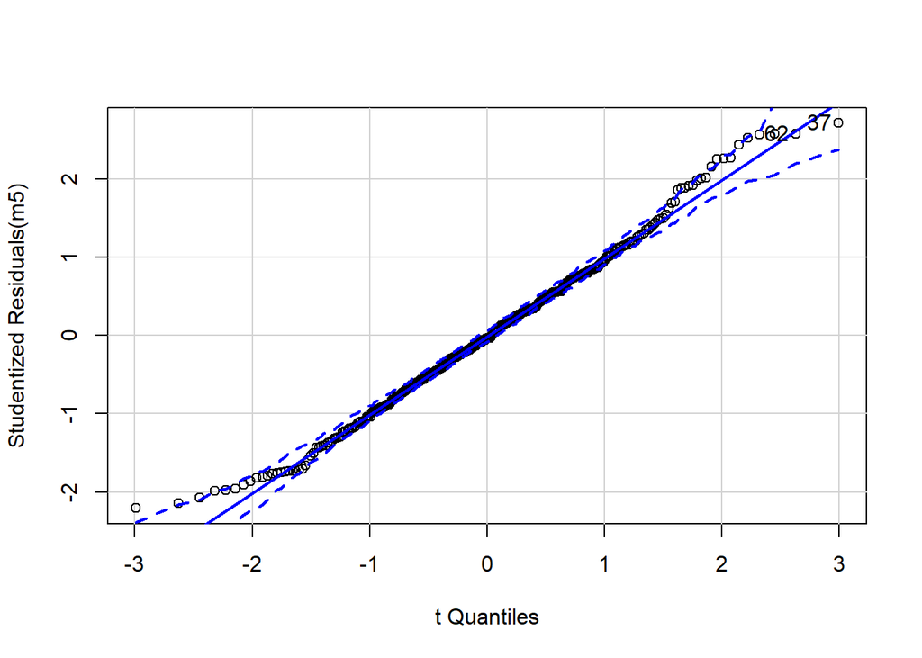

```
## [1] 37 62
```

```r
# qqnorm com envelope.
qqPlot(m5)
```

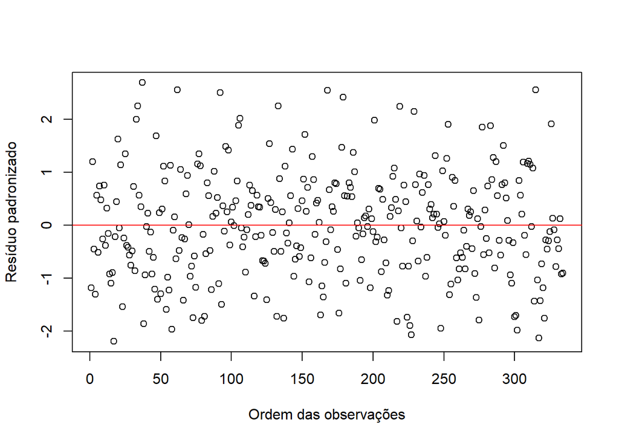

```r
# Resíduo padronizado
plot(rstandard(m5),
     xlab = "Ordem das observações",
     ylab = "Resíduo padronizado")
abline(h = c(-3, 3), col = "red", lty = 2)
abline(h = 0, col = "red", lty = 1)
```

No modelo m5 todas as observações atendem ao critério de normalidade, a distribuição da variância dos resíduos é mais próxima a uma constante e não há problemas significativos com alavancagem.  
O próximo passo é fazer a melhor transformação das variáveis considerando três modelos, são eles: o modelo com seis variáveis preditoras, o modelo com cinco variáveis preditoras e o modelo com quatro variáveis preditoras.

```r
### Modelos
m6p <- lm(Preco ~ Avaliacao + Dias + nAvaliacao + Paginas + Idioma + TipoLivro, data = dados5)
summary(m6p)
```

```
##
## Call:
## lm(formula = Preco ~ Avaliacao + Dias + nAvaliacao + Paginas +
##     Idioma + TipoLivro, data = dados5)
##
## Residuals:
##      Min       1Q   Median       3Q      Max
## -220.038  -69.910   -3.379   68.368  272.435
##
## Coefficients:
##                       Estimate  Std. Error t value             Pr(>|t|)
## (Intercept)         184.716698   60.092015   3.074              0.00229 **
## Avaliacao           -12.110890   14.230468  -0.851              0.39536
## Dias                 -0.001514    0.002995  -0.505              0.61363
## nAvaliacao           -0.106755    0.020961  -5.093         0.0000005963 ***
## Paginas               0.380070    0.033965  11.190 < 0.0000000000000002 ***
## IdiomaPortugues    -185.782480   17.589377 -10.562 < 0.0000000000000002 ***
## TipoLivroCapa dura   89.820631   15.483111   5.801         0.0000000155 ***
## ---
## Signif. codes:  0 '***' 0.001 '**' 0.01 '*' 0.05 '.' 0.1 ' ' 1
##
## Residual standard error: 104.2 on 327 degrees of freedom
## Multiple R-squared:  0.5087, Adjusted R-squared:  0.4997
## F-statistic: 56.43 on 6 and 327 DF,  p-value: < 0.00000000000000022
```

```r
m5p <- lm(Preco ~ Dias + nAvaliacao + Paginas + Idioma + TipoLivro, data = dados5)
summary(m5p)
```

```
##
## Call:
## lm(formula = Preco ~ Dias + nAvaliacao + Paginas + Idioma + TipoLivro,
##     data = dados5)
##
## Residuals:
##      Min       1Q   Median       3Q      Max
## -220.714  -69.373   -3.966   68.654  289.300
##
## Coefficients:
##                       Estimate  Std. Error t value             Pr(>|t|)
## (Intercept)         135.091830   14.519822   9.304 < 0.0000000000000002 ***
## Dias                 -0.001368    0.002989  -0.458                0.648
## nAvaliacao           -0.109979    0.020607  -5.337          0.000000177 ***
## Paginas               0.372111    0.032638  11.401 < 0.0000000000000002 ***
## IdiomaPortugues    -186.848736   17.537325 -10.654 < 0.0000000000000002 ***
## TipoLivroCapa dura   89.682383   15.475750   5.795          0.000000016 ***
## ---
## Signif. codes:  0 '***' 0.001 '**' 0.01 '*' 0.05 '.' 0.1 ' ' 1
##
## Residual standard error: 104.2 on 328 degrees of freedom
## Multiple R-squared:  0.5076, Adjusted R-squared:  0.5001
## F-statistic: 67.63 on 5 and 328 DF,  p-value: < 0.00000000000000022
```

```r
m4p <- lm(Preco ~ nAvaliacao + Paginas + Idioma + TipoLivro, data = dados5)
summary(m4p)
```

```
##
## Call:
## lm(formula = Preco ~ nAvaliacao + Paginas + Idioma + TipoLivro,
##     data = dados5)
##
## Residuals:
##      Min       1Q   Median       3Q      Max
## -235.543  -68.847   -3.885   68.594  289.943
##
## Coefficients:
##                      Estimate Std. Error t value             Pr(>|t|)
## (Intercept)         133.84941   14.24660   9.395 < 0.0000000000000002 ***
## nAvaliacao           -0.11078    0.02051  -5.401         0.0000001270 ***
## Paginas               0.37036    0.03237  11.440 < 0.0000000000000002 ***
## IdiomaPortugues    -187.18947   17.50045 -10.696 < 0.0000000000000002 ***
## TipoLivroCapa dura   89.84736   15.45295   5.814         0.0000000144 ***
## ---
## Signif. codes:  0 '***' 0.001 '**' 0.01 '*' 0.05 '.' 0.1 ' ' 1
##
## Residual standard error: 104 on 329 degrees of freedom
## Multiple R-squared:  0.5073, Adjusted R-squared:  0.5013
## F-statistic: 84.69 on 4 and 329 DF,  p-value: < 0.00000000000000022
```

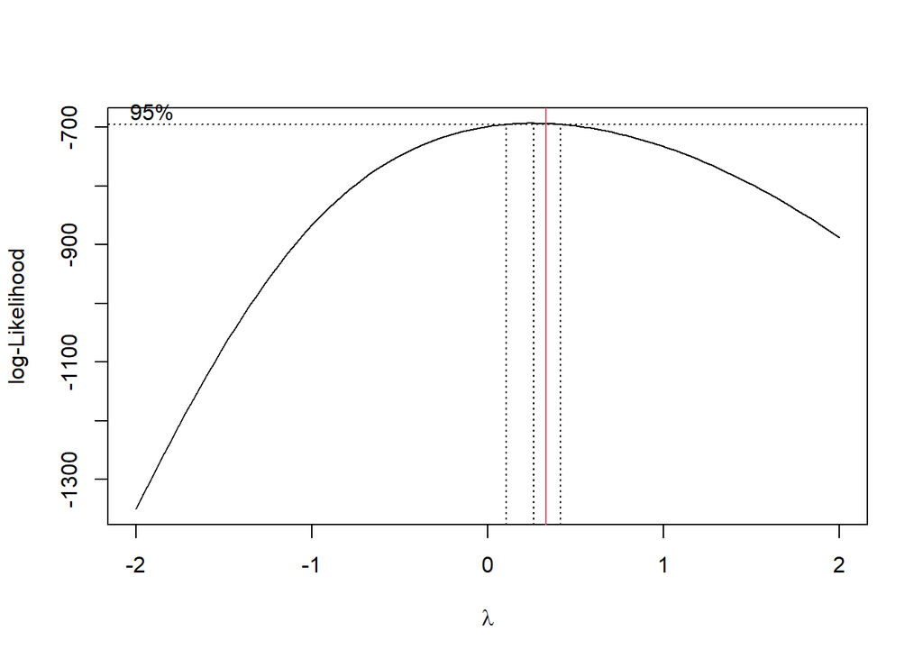

```r
### Transformação
# 6 preditoras
MASS::boxcox(m6p)
abline(v = 1/3, col = 2)
```

```r
m6_t <- update(m6p, . ^ (1/3) ~ .)
summary(m6_t)
```

```
##
## Call:
## lm(formula = Preco^(1/3) ~ Avaliacao + Dias + nAvaliacao + Paginas +
##     Idioma + TipoLivro, data = dados5)
##
## Residuals:
##      Min       1Q   Median       3Q      Max
## -2.12343 -0.52739  0.04809  0.58100  2.03556
##
## Coefficients:
##                       Estimate  Std. Error t value             Pr(>|t|)
## (Intercept)         5.07157937  0.50452468  10.052 < 0.0000000000000002 ***
## Avaliacao           0.01488684  0.11947715   0.125                0.901
## Dias               -0.00002373  0.00002515  -0.944                0.346
## nAvaliacao         -0.00103166  0.00017598  -5.862         0.0000000112 ***
## Paginas             0.00326211  0.00028516  11.439 < 0.0000000000000002 ***
## IdiomaPortugues    -2.05703821  0.14767810 -13.929 < 0.0000000000000002 ***
## TipoLivroCapa dura  0.60063691  0.12999417   4.620         0.0000055151 ***
## ---
## Signif. codes:  0 '***' 0.001 '**' 0.01 '*' 0.05 '.' 0.1 ' ' 1
##
## Residual standard error: 0.8749 on 327 degrees of freedom
## Multiple R-squared:  0.5625, Adjusted R-squared:  0.5545
## F-statistic: 70.08 on 6 and 327 DF,  p-value: < 0.00000000000000022
```

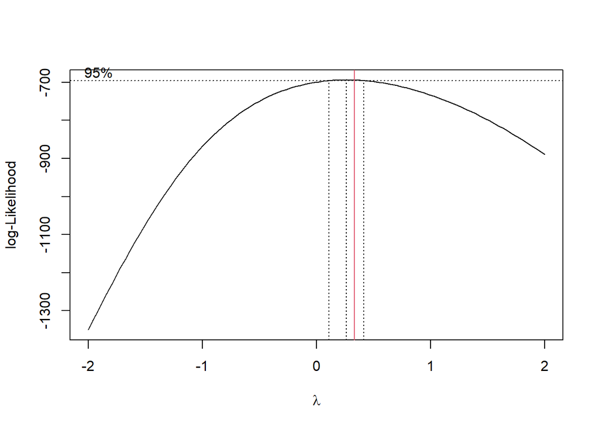

```r
# 5 preditoras
MASS::boxcox(m5p)
abline(v = 1/3, col = 2)
```

```r
m5_t <- update(m5p, . ^ (1/3) ~ .)
summary(m5_t)
```

```
##
## Call:
## lm(formula = Preco^(1/3) ~ Dias + nAvaliacao + Paginas + Idioma +
##     TipoLivro, data = dados5)
##
## Residuals:
##     Min      1Q  Median      3Q     Max
## -2.1138 -0.5285  0.0471  0.5757  2.0383
##
## Coefficients:
##                       Estimate  Std. Error t value             Pr(>|t|)
## (Intercept)         5.13257880  0.12177462  42.148 < 0.0000000000000002 ***
## Dias               -0.00002391  0.00002507  -0.954                0.341
## nAvaliacao         -0.00102770  0.00017283  -5.946        0.00000000702 ***
## Paginas             0.00327189  0.00027373  11.953 < 0.0000000000000002 ***
## IdiomaPortugues    -2.05572756  0.14708178 -13.977 < 0.0000000000000002 ***
## TipoLivroCapa dura  0.60080685  0.12979179   4.629        0.00000530087 ***
## ---
## Signif. codes:  0 '***' 0.001 '**' 0.01 '*' 0.05 '.' 0.1 ' ' 1
##
## Residual standard error: 0.8736 on 328 degrees of freedom
## Multiple R-squared:  0.5625, Adjusted R-squared:  0.5559
## F-statistic: 84.35 on 5 and 328 DF,  p-value: < 0.00000000000000022
```

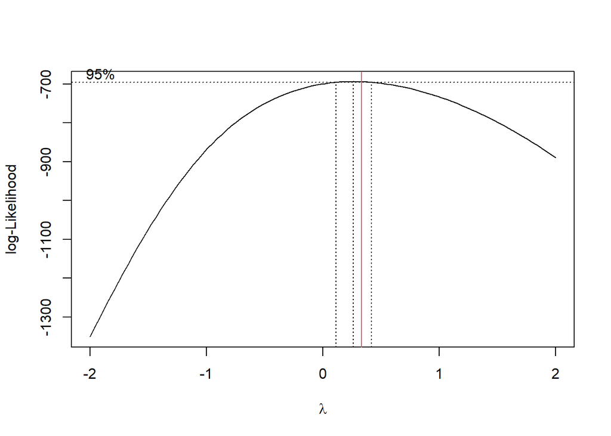

```r
# 4 preditoras
MASS::boxcox(m4p)
abline(v = 1/3, col = 2)
```

```r
m4_t <- update(m4p, . ^ (1/3) ~ .)
summary(m4_t)
```

```
##
## Call:
## lm(formula = Preco^(1/3) ~ nAvaliacao + Paginas + Idioma + TipoLivro,
##     data = dados5)
##
## Residuals:
##      Min       1Q   Median       3Q      Max
## -2.28409 -0.50240  0.04744  0.57162  2.04108
##
## Coefficients:
##                      Estimate Std. Error t value             Pr(>|t|)
## (Intercept)         5.1108594  0.1196106  42.729 < 0.0000000000000002 ***
## nAvaliacao         -0.0010416  0.0001722  -6.050        0.00000000395 ***
## Paginas             0.0032413  0.0002718  11.925 < 0.0000000000000002 ***
## IdiomaPortugues    -2.0616842  0.1469290 -14.032 < 0.0000000000000002 ***
## TipoLivroCapa dura  0.6036909  0.1297388   4.653        0.00000474577 ***
## ---
## Signif. codes:  0 '***' 0.001 '**' 0.01 '*' 0.05 '.' 0.1 ' ' 1
##
## Residual standard error: 0.8735 on 329 degrees of freedom
## Multiple R-squared:  0.5613, Adjusted R-squared:  0.556
## F-statistic: 105.2 on 4 and 329 DF,  p-value: < 0.00000000000000022
```

Os modelos transformados não consideram as observações que tiveram problemas na análise de diagnóstico. Na escolha do modelo com 5 variáveis, foi excluída a variável que apresentava o maior p-valor com base na função *summary(m6_t)* (Avaliacao), do mesmo modo, para o modelo com 4 variáveis foi excluída a que apresentava o maior p-valor baseado na função *summary(m5_t)* (Dias). Em todos os modelos a transformação de Box-Cox indicada foi a raiz cúbica.

```r
n <- 334
# Coeficiente de determinação ajustado m6_t (6 preditoras)
summary(m6_t)
```

```
##
## Call:
## lm(formula = Preco^(1/3) ~ Avaliacao + Dias + nAvaliacao + Paginas +
##     Idioma + TipoLivro, data = dados5)
##
## Residuals:
##      Min       1Q   Median       3Q      Max
## -2.12343 -0.52739  0.04809  0.58100  2.03556
##
## Coefficients:
##                       Estimate  Std. Error t value             Pr(>|t|)
## (Intercept)         5.07157937  0.50452468  10.052 < 0.0000000000000002 ***
## Avaliacao           0.01488684  0.11947715   0.125                0.901
## Dias               -0.00002373  0.00002515  -0.944                0.346
## nAvaliacao         -0.00103166  0.00017598  -5.862         0.0000000112 ***
## Paginas             0.00326211  0.00028516  11.439 < 0.0000000000000002 ***
## IdiomaPortugues    -2.05703821  0.14767810 -13.929 < 0.0000000000000002 ***
## TipoLivroCapa dura  0.60063691  0.12999417   4.620         0.0000055151 ***
## ---
## Signif. codes:  0 '***' 0.001 '**' 0.01 '*' 0.05 '.' 0.1 ' ' 1
##
## Residual standard error: 0.8749 on 327 degrees of freedom
## Multiple R-squared:  0.5625, Adjusted R-squared:  0.5545
## F-statistic: 70.08 on 6 and 327 DF,  p-value: < 0.00000000000000022
```

```r
p <- 6
R2 <- 0.5625
R2_Aj <- 1 - ((n - 1) / (n - p)) * (1 - R2) ; R2_Aj
```

```
## [1] 0.5558308
```

```r
# Coeficiente de determinação ajustado m5_t (5 preditoras)
summary(m5_t)
```

```
##
## Call:
## lm(formula = Preco^(1/3) ~ Dias + nAvaliacao + Paginas + Idioma +
##     TipoLivro, data = dados5)
##
## Residuals:
##     Min      1Q  Median      3Q     Max
## -2.1138 -0.5285  0.0471  0.5757  2.0383
##
## Coefficients:
##                       Estimate  Std. Error t value             Pr(>|t|)
## (Intercept)         5.13257880  0.12177462  42.148 < 0.0000000000000002 ***
## Dias               -0.00002391  0.00002507  -0.954                0.341
## nAvaliacao         -0.00102770  0.00017283  -5.946        0.00000000702 ***
## Paginas             0.00327189  0.00027373  11.953 < 0.0000000000000002 ***
## IdiomaPortugues    -2.05572756  0.14708178 -13.977 < 0.0000000000000002 ***
## TipoLivroCapa dura  0.60080685  0.12979179   4.629        0.00000530087 ***
## ---
## Signif. codes:  0 '***' 0.001 '**' 0.01 '*' 0.05 '.' 0.1 ' ' 1
##
## Residual standard error: 0.8736 on 328 degrees of freedom
## Multiple R-squared:  0.5625, Adjusted R-squared:  0.5559
## F-statistic: 84.35 on 5 and 328 DF,  p-value: < 0.00000000000000022
```

```r
p <- 5
R2 <- 0.5625
R2_Aj <- 1 - ((n - 1) / (n - p)) * (1 - R2) ; R2_Aj
```

```
## [1] 0.5571809
```

```r
# Coeficiente de determinação ajustado m4_t (4 preditoras)
summary(m4_t)
```

```
##
## Call:
## lm(formula = Preco^(1/3) ~ nAvaliacao + Paginas + Idioma + TipoLivro,
##     data = dados5)
##
## Residuals:
##      Min       1Q   Median       3Q      Max
## -2.28409 -0.50240  0.04744  0.57162  2.04108
##
## Coefficients:
##                      Estimate Std. Error t value             Pr(>|t|)
## (Intercept)         5.1108594  0.1196106  42.729 < 0.0000000000000002 ***
## nAvaliacao         -0.0010416  0.0001722  -6.050        0.00000000395 ***
## Paginas             0.0032413  0.0002718  11.925 < 0.0000000000000002 ***
## IdiomaPortugues    -2.0616842  0.1469290 -14.032 < 0.0000000000000002 ***
## TipoLivroCapa dura  0.6036909  0.1297388   4.653        0.00000474577 ***
## ---
## Signif. codes:  0 '***' 0.001 '**' 0.01 '*' 0.05 '.' 0.1 ' ' 1
##
## Residual standard error: 0.8735 on 329 degrees of freedom
## Multiple R-squared:  0.5613, Adjusted R-squared:  0.556
## F-statistic: 105.2 on 4 and 329 DF,  p-value: < 0.00000000000000022
```

```r
p <- 4
R2 <- 0.5613
R2_Aj <- 1 - ((n - 1) / (n - p)) * (1 - R2) ; R2_Aj
```

```
## [1] 0.5573118
```

O critério utilizado para a seleção de covariáveis do modelo é o coeficiente de determinação ajustado, que analisa qual é a quantidade de covariáveis indicada para o modelo.  
O valor do R<sup>2</sup><sub>Aj</sub> para os três casos foi muito próximo, porém optou-se por considerar o maior deles. Sendo assim, o modelo selecionado é m4_t que possui 4 covariáveis.

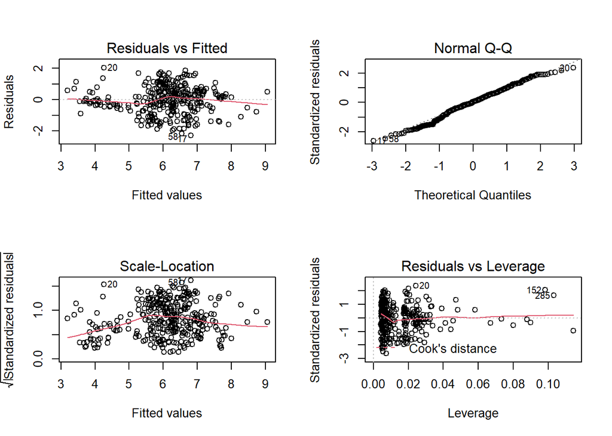

```r
# Gráficos m4_t
par(mfrow = c(2, 2))
plot(m4_t)
```

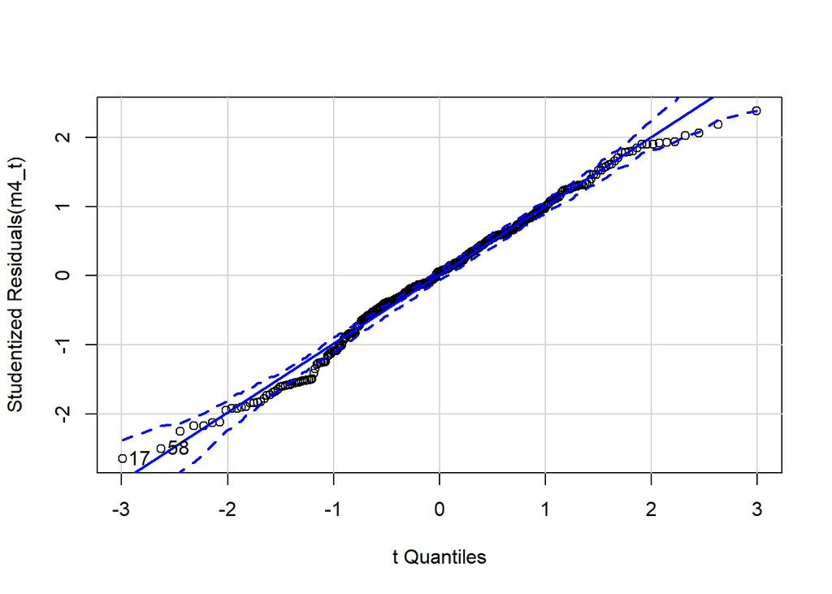

```
## [1] 17 58
```

```r
layout(1)
qqPlot(m4_t)
```

#### Interpretação

**Parâmetros do modelo:**

```r
summary(m4p)
```

```
##
## Call:
## lm(formula = Preco ~ nAvaliacao + Paginas + Idioma + TipoLivro,
##     data = dados5)
##
## Residuals:
##      Min       1Q   Median       3Q      Max
## -235.543  -68.847   -3.885   68.594  289.943
##
## Coefficients:
##                      Estimate Std. Error t value             Pr(>|t|)
## (Intercept)         133.84941   14.24660   9.395 < 0.0000000000000002 ***
## nAvaliacao           -0.11078    0.02051  -5.401         0.0000001270 ***
## Paginas               0.37036    0.03237  11.440 < 0.0000000000000002 ***
## IdiomaPortugues    -187.18947   17.50045 -10.696 < 0.0000000000000002 ***
## TipoLivroCapa dura   89.84736   15.45295   5.814         0.0000000144 ***
## ---
## Signif. codes:  0 '***' 0.001 '**' 0.01 '*' 0.05 '.' 0.1 ' ' 1
##
## Residual standard error: 104 on 329 degrees of freedom
## Multiple R-squared:  0.5073, Adjusted R-squared:  0.5013
## F-statistic: 84.69 on 4 and 329 DF,  p-value: < 0.00000000000000022
```

Interpretação dos parâmetros do modelo:

Quando o número de páginas aumenta uma unidade, o preço do livro aumenta R$0,37 em média.

Livros cujo o idioma é português são em média R$187,19 mais baratos do que livros publicados em inglês.

O aumento do número de avaliações do livro em uma unidade, diminui o seu preço em R$0,11 em média.

Quanto ao coeficiente de determinação do modelo ser 0,507, isso significa que apesar das quatro covariáveis terem relação com o preço dos livros, existem outras variáveis a qual não tivemos acesso que também influenciam no valor final do produto.

**Estimativas do modelo:**

$E(Y|x) = \beta_0 + \beta_1x_1 + \beta_2x_2$

$E(Y|x) = (\beta_0 + \beta_3) + \beta_1x_1 + \beta_2x_2$

$E(Y|x) = (\beta_0 + \beta_4) + \beta_1x_1 + \beta_2x_2$

$E(Y|x) = (\beta_0 + \beta_3 + \beta_4) + \beta_1x_1 + \beta_2x_2$

Considerando $\beta_0$ o intercepto, $\beta_1$ o número de avaliações no site da Amazon, $\beta_2$ o número de páginas, $\beta_3$ o idioma em que o livro foi publicado e $\beta_4$ tipo de capa que o livro possui.

As estimativas do modelo foram consideradas a partir da combinação das covariáveis categóricas, portanto o o preço de livros de ciência de dados e estatística são estimados pelo modelo da seguinte maneira:

$E(Y|x) = 133.85 - 0.11 x_1 + 0.37 x_2$, se o idioma é inglês e a capa é comum.

$E(Y|x) = (133.85 - 187.19) - 0.11x_1 + 0.37 x_2$, se o idioma é português e a capa é comum.

$E(Y|x) = (133.85 + 89.85) - 0.11x_1 + 0.37 x_2$, se o idioma é inglês e a capa é dura.

$E(Y|x) = (133.85 - 187.19 + 89.85) - 0.11x_1 + 0.37 x_2$, se o idioma é português e a capa é dura.

## Conclusão

Feita a análise dos dados, chegamos a um modelo com 4 parâmetros e um coeficiente de determinação de 0,507. Significando que nós não tivemos acesso a outras informações que poderiam contribuir para o valor do preço.

As covariáveis significativas do nosso modelo são as nossas duas categóricas, *Idioma* e *TipoLivro*, e as duas númericas *nAvaliação* e *Paginas*. Logo, as hipóteses levantadas na introdução não foram rejeitadas.

Concluímos está análise com uma sugestão de estudo futuro, que seria a coleta de mais dados do site com o objetivo de identificar quais outras variáveis interferem no preço dos livros.